# Practicak Machine Learning: Final Project

Denitsa Panova

June 20, 2017

# Executive Summary

The scope of the following paper is to see how well people perform certain activities. The data which is used is taken from a group of enthusiasts who record their movements. More information about the data and how it is collected can be found [here.](http://groupware.les.inf.puc-rio.br/har) In this report we explore the data to identify how well (**classe** variable) activities are performed. The second objective is to find which machine learning algorithm predicts how well 20 out-of-sample activities are performed. We try three approaches - Decision Trees, Random Forest and GBM. The best one (relying on the out-of-sample accuracy and overfiting) is GBM.

# Data

### Import Data and Packages

```r
library(caret); library(rpart);library(rpart.plot);library(randomForest);library(corrplot)
```

Let’s import data from url.

```r
#urls
url_train <- "http://d396qusza40orc.cloudfront.net/predmachlearn/pml-training.csv"
url_test <- "http://d396qusza40orc.cloudfront.net/predmachlearn/pml-testing.csv"
train_full = read.csv(url(url_train), stringsAsFactors = FALSE)
test = read.csv(url(url_test),stringsAsFactors = FALSE)
```

### Data Exploration and Processing

The data set have 160 columns.Let’s investigate them.

```r
colnames(train_full)[1:10]
```

```
##  [1] "X"                    "user_name"            "raw_timestamp_part_1"
##  [4] "raw_timestamp_part_2" "cvtd_timestamp"       "new_window"
##  [7] "num_window"           "roll_belt"            "pitch_belt"
## [10] "yaw_belt"
```

The first five are connected to the person or time specific information. For the purposes of this report, we will consider that these factors are irrelevant. Other columns which needs to be removed are those which have to many NAs or zeros. We shall exclude columns with more than 95% of NAs.

```r
col_to_remove = colnames(train_full)[1:5] #taking the first five

train_full= train_full[,!(colnames(train_full)%in%col_to_remove)]

#Need to transform some columns from factor to numerical

columns_not_to_numeric = c('new_window','classe')

for(c in colnames(train_full)){
  if(!(c %in% columns_not_to_numeric)){
    train_full[,c] = as.numeric(train_full[,c])
    test[,c] = as.numeric(test[,c])
  }
}

col_to_remove = c()
#checking which columns have 95% NA or zero coverage
for(cname in colnames(train_full)){
  if(sum(is.na(train_full[,cname])) > 0.95*(nrow(train_full) | sum(train_full[,cname]==0) > 0.95*(nrow(train_full)))) {
    col_to_remove = c(col_to_remove,cname)
  }
}
length(col_to_remove)
```

```
## [1] 100
```

```r
#train/validate
set.seed(666)
train_index <- createDataPartition(train_full$classe, p=0.8, list=FALSE)
train <- train_full[train_index, ]
validate <- train_full[-train_index, ]
train = train[,!(colnames(train)%in%col_to_remove)]
validate = validate[,!(colnames(validate)%in%col_to_remove)]
```

We investigate the correlation between the remaining vairables.

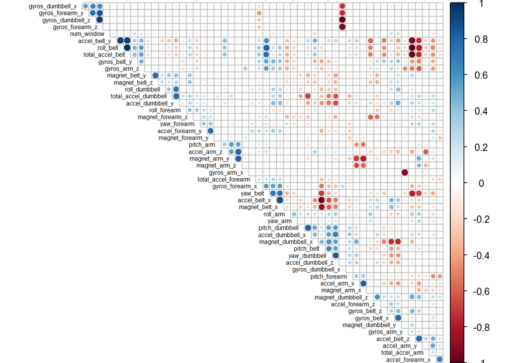

```r
cor_mat = cor(train[,!(colnames(train)%in%columns_not_to_numeric)])
corrplot(cor_mat,type = "upper", tl.pos = "td",
         method = "circle", tl.cex = 0.5, tl.col = 'black',
         order = "hclust", diag = FALSE)
```

Note: **there is observed correlation between some of the variables.** Yet, we shall use all of the remaining variables since we are not sure which ones to remove.

# Models

We shall consider three models and in the subsequent section we will test the chosen model on the test set. Moreover, we shall consider 5 fold cross-validation for all of them.

### Decision Trees

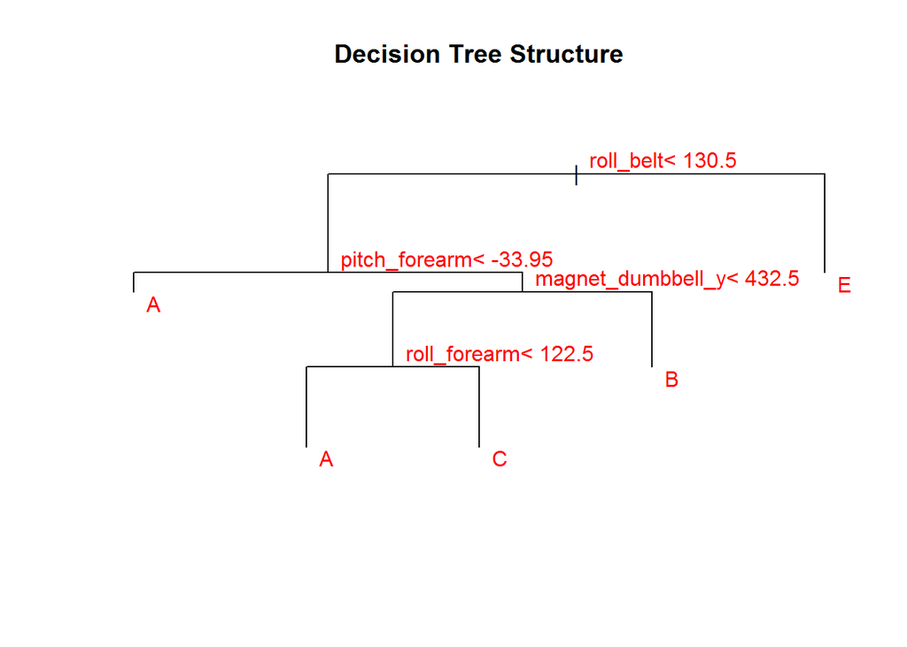

```r
control_models <- trainControl(method = "cv", number = 5)
decision_tree <- train(classe ~ .,
                       data = train,
                       method = "rpart",
                       trControl = control_models)
#plot the tree
plot(decision_tree$finalModel, main = 'Decision Tree Structure', asp = 5)
text(decision_tree$finalModel, pos = 4, col= 'red')
```

We observe that the model separates on 4 major variables (based on their importance). Those variables are roll_bell, pitch_forearm, magnet_dumbbell and roll_forearm. Now let’s predict on the validation dataset and see the confusion matrix

```r
# predict validation set
predict_decision_tree <- predict(decision_tree, validate)
# Confusion Matrix Accuracy
confusionMatrix(validate$classe, predict_decision_tree)$overall[1]
```

```
##  Accuracy
## 0.5011471
```

### Random Forest

```r
rf <- train(classe ~ .,
            data = train,
            method = "rf",
            trControl = control_models)
# predict validation set
predict_rf <- predict(rf, validate)
# Confusion Matrix
confusionMatrix(validate$classe, predict_rf)$overall[1]
```

```
## Accuracy
## 0.997196
```

The out-of-sample accuracy is 99.7 It is classifying everything almost perfectly, which would suggest for **overfitting** (the complete confusion matrix is available in teh appendix). **Yet, we for now we conclude that this is appropriate model.** As we have seen in our investigation of the dataset, many of the factors are correlated, threfore, random forest, which take cares of that is performing really well.

### GBM

```r
gbm <- train(classe ~ .,
            data = train,
            method = "gbm",
            trControl = control_models,
            verbose = FALSE)
# predict validation set
predict_gbm <- predict(gbm, validate)
# Confusion Matrix
confusionMatrix(validate$classe, predict_gbm)$overall[1]
```

```
##  Accuracy
## 0.9859801
```

The out-of-sample accuracy is 98.6% which is less than the Random forest one. Yet, the predictions are not as acccurate as the ranodm forest ones, suggesting that GBM is not overfitting the model to that extend.(the complete confusion matrix is available in the appendix). Therefore, we can conclude that this is the model which we appoint as **the most appropriate.**

# Predicting the Test DataSet Resluts

To re-evaluate the model accuracy, we shall predict the test results.

```r
# predict on test set
preds <- predict(gbm, newdata=test)
preds
```

```
##  [1] B A B A A E D B A A B C B A E E A B B B
## Levels: A B C D E
```

# Appendix

## Decision Tree

### Model

```r
decision_tree$finalModel
```

```
## n= 15699
##
## node), split, n, loss, yval, (yprob)
##       * denotes terminal node
##
##  1) root 15699 11235 A (0.28 0.19 0.17 0.16 0.18)
##    2) roll_belt< 130.5 14388  9937 A (0.31 0.21 0.19 0.18 0.11)
##      4) pitch_forearm< -33.95 1270     7 A (0.99 0.0055 0 0 0) *
##      5) pitch_forearm>=-33.95 13118  9930 A (0.24 0.23 0.21 0.2 0.12)
##       10) magnet_dumbbell_y< 432.5 11007  7901 A (0.28 0.18 0.24 0.19 0.11)
##         20) roll_forearm< 122.5 6791  4019 A (0.41 0.18 0.19 0.17 0.06) *
##         21) roll_forearm>=122.5 4216  2845 C (0.079 0.18 0.33 0.23 0.19) *
##       11) magnet_dumbbell_y>=432.5 2111  1049 B (0.039 0.5 0.043 0.23 0.19) *
##    3) roll_belt>=130.5 1311    13 E (0.0099 0 0 0 0.99) *
```

### Confusion Matrix

```r
confusionMatrix(validate$classe, predict_decision_tree)
```

```
## Confusion Matrix and Statistics
##
##           Reference
## Prediction    A    B    C    D    E
##          A 1020   25   70    0    1
##          B  322  258  179    0    0
##          C  305   24  355    0    0
##          D  289  124  230    0    0
##          E  110  101  177    0  333
##
## Overall Statistics
##
##                Accuracy : 0.5011
##                  95% CI : (0.4854, 0.5169)
##     No Information Rate : 0.5215
##     P-Value [Acc > NIR] : 0.9949
##
##                   Kappa : 0.3477
##  Mcnemar's Test P-Value : NA
##
## Statistics by Class:
##
##                      Class: A Class: B Class: C Class: D Class: E
## Sensitivity            0.4985  0.48496  0.35114       NA  0.99701
## Specificity            0.9489  0.85226  0.88702   0.8361  0.89189
## Pos Pred Value         0.9140  0.33992  0.51901       NA  0.46186
## Neg Pred Value         0.6345  0.91340  0.79747       NA  0.99969
## Prevalence             0.5215  0.13561  0.25771   0.0000  0.08514
## Detection Rate         0.2600  0.06577  0.09049   0.0000  0.08488
## Detection Prevalence   0.2845  0.19347  0.17436   0.1639  0.18379
## Balanced Accuracy      0.7237  0.66861  0.61908       NA  0.94445
```

## Random Forest

### Model

```r
rf$finalModel
```

```
##
## Call:
##  randomForest(x = x, y = y, mtry = param$mtry)
##                Type of random forest: classification
##                      Number of trees: 500
## No. of variables tried at each split: 28
##
##         OOB estimate of  error rate: 0.19%
## Confusion matrix:
##      A    B    C    D    E  class.error
## A 4462    1    0    0    1 0.0004480287
## B    4 3030    3    1    0 0.0026333114
## C    0    6 2730    2    0 0.0029218408
## D    0    0    6 2566    1 0.0027205597
## E    0    0    0    5 2881 0.0017325017
```

### Confusion Matrix

```r
confusionMatrix(validate$classe, predict_rf)
```

```
## Confusion Matrix and Statistics
##
##           Reference
## Prediction    A    B    C    D    E
##          A 1116    0    0    0    0
##          B    5  753    1    0    0
##          C    0    0  684    0    0
##          D    0    0    4  639    0
##          E    0    0    0    1  720
##
## Overall Statistics
##
##                Accuracy : 0.9972
##                  95% CI : (0.995, 0.9986)
##     No Information Rate : 0.2858
##     P-Value [Acc > NIR] : < 2.2e-16
##
##                   Kappa : 0.9965
##  Mcnemar's Test P-Value : NA
##
## Statistics by Class:
##
##                      Class: A Class: B Class: C Class: D Class: E
## Sensitivity            0.9955   1.0000   0.9927   0.9984   1.0000
## Specificity            1.0000   0.9981   1.0000   0.9988   0.9997
## Pos Pred Value         1.0000   0.9921   1.0000   0.9938   0.9986
## Neg Pred Value         0.9982   1.0000   0.9985   0.9997   1.0000
## Prevalence             0.2858   0.1919   0.1756   0.1631   0.1835
## Detection Rate         0.2845   0.1919   0.1744   0.1629   0.1835
## Detection Prevalence   0.2845   0.1935   0.1744   0.1639   0.1838
## Balanced Accuracy      0.9978   0.9991   0.9964   0.9986   0.9998
```

## GBM

### Model

```r
gbm$finalModel
```

```
## A gradient boosted model with multinomial loss function.
## 150 iterations were performed.
## There were 54 predictors of which 38 had non-zero influence.
```

### Confusion Matrix

```r
confusionMatrix(validate$classe, predict_gbm)
```

```
## Confusion Matrix and Statistics
##
##           Reference
## Prediction    A    B    C    D    E
##          A 1112    4    0    0    0
##          B   14  736    9    0    0
##          C    0    1  680    2    1
##          D    0    1   12  630    0
##          E    0    2    2    7  710
##
## Overall Statistics
##
##                Accuracy : 0.986
##                  95% CI : (0.9818, 0.9894)
##     No Information Rate : 0.287
##     P-Value [Acc > NIR] : < 2.2e-16
##
##                   Kappa : 0.9823
##  Mcnemar's Test P-Value : NA
##
## Statistics by Class:
##
##                      Class: A Class: B Class: C Class: D Class: E
## Sensitivity            0.9876   0.9892   0.9673   0.9859   0.9986
## Specificity            0.9986   0.9928   0.9988   0.9960   0.9966
## Pos Pred Value         0.9964   0.9697   0.9942   0.9798   0.9847
## Neg Pred Value         0.9950   0.9975   0.9929   0.9973   0.9997
## Prevalence             0.2870   0.1897   0.1792   0.1629   0.1812
## Detection Rate         0.2835   0.1876   0.1733   0.1606   0.1810
## Detection Prevalence   0.2845   0.1935   0.1744   0.1639   0.1838
## Balanced Accuracy      0.9931   0.9910   0.9830   0.9910   0.9976
```